# 计算机视觉实践 第3次课，作者：邓擎琼

# 本次课我们将学到：

得到更完整的人脸轮廓，准确分割出人脸；同理得到人的轮廓和分割结果。

上节课得到的人脸轮廓：

[figure not shown]

这节课得到的人脸轮廓及人脸分割结果：

[figure not shown]

以及人的轮廓和分割结果：

[figure not shown]

```python
#先导入相关的库，定义显示图像函数
import cv2
import numpy as np
import matplotlib.pyplot as plt

def cv_show(name,img): #窗口名字，图像
    cv2.imshow(name,img)
    cv2.waitKey(0)
    cv2.destroyAllWindows()

def plt_show(name, img, sub=111): #标题，图像，子窗口id
    plt.subplot(sub)
    plt.imshow(cv2.cvtColor(img, cv2.COLOR_BGR2RGB))
    plt.title(name)
    plt.axis("off")
    if (sub-100)//10==(sub-100)%10:
        plt.show()
```

```
轮廓数量： 33
```

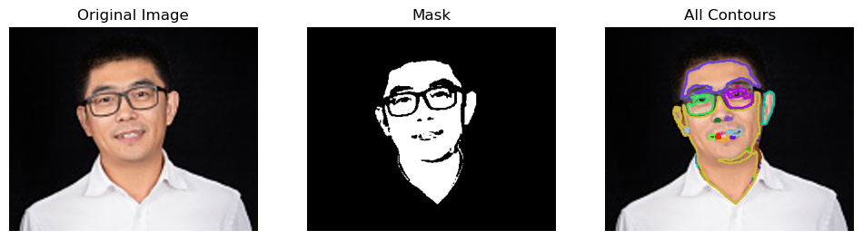

```python
'''眼镜男的轮廓提取'''
imgGlass = cv2.imread("Images/Glasses.png")
plt.figure(figsize=(12,10))
plt_show('Original Image', imgGlass, 131)

#肤色检测
img_hsv = cv2.cvtColor(imgGlass, cv2.COLOR_BGR2HSV)
lower = np.array([0, 31, 173], dtype = "uint8")
upper = np.array([78, 255, 255], dtype = "uint8")
mask = cv2.inRange(img_hsv, lower, upper)
plt_show('Mask', mask, 132)

#获取轮廓并绘制
contours, hier = cv2.findContours(mask, cv2.RETR_LIST, cv2.CHAIN_APPROX_SIMPLE)

print('轮廓数量：', len(contours))

imgGlassContours = imgGlass.copy()
for i in range(len(contours)):
    cv2.drawContours(imgGlassContours, contours, i, (np.random.randint(0,255), np.random.randint(0,255), np.random.randint(0,255)), 2)
plt_show("All Contours", imgGlassContours, 133)
```

## **1. 图像滤波**

图像滤波是图像处理的重要部分，在图像预处理方面应用广泛，图像滤波的好坏决定后续结果的好坏。

- 滤波实际上是信号处理的一个概念，图像可以看成一个二维信号，其中像素点的灰度值代表信号的强弱；
- 高频：图像上变化剧烈的部分；
- 低频：图像灰度值变化缓慢，平坦的地方；
- 根据图像高低频，设置高通和低通滤波器。高通滤波器可以检测变化尖锐，明显的地方，低通可以让图像变得平滑，消除噪声；
- 滤波作用：低通滤波器用于图像平滑去噪，高通滤波器用于边缘检测；

### **1.1 低通滤波（图形平滑去噪）**

假设： 噪声是独立同分布的。

常见的噪声有高斯噪声、‌泊松噪声、椒盐噪声等。

[figure not shown]

分类：

- 线性滤波：方框滤波/均值滤波/高斯滤波；
- 非线性滤波：中值滤波/双边滤波；

参考文档：https://docs.opencv.org/4.x/d4/d13/tutorial_py_filtering.html

[figure not shown]

各种边界扩展模式对应的值见：https://docs.opencv.org/4.x/d2/de8/group__core__array.html#ga209f2f4869e304c82d07739337eae7c5

[figure not shown]

#### 1.1.1 卷积操作

通用API：cv2.filter2D( src, ddepth, kernel[, dst[, anchor[, delta[, borderType]]]] ) -> dst

- src：原图
- ddepth：目标图像深度（存储每个像素所用的位数），-1表示同src的深度
- kernel：卷积核
- dst：结果图像
- anchor：锚点，Point(-1,-1)表示在核中心
- delta：调节增量
- borderType：边界填充方式

[figure not shown]

```python
img = cv2.imread('Images/LenaNoiseGauss.png')
plt_show('Original', img, 121)

kernel = np.ones((3,3),np.float32)/9  #即3*3的均值滤波
dst = cv2.filter2D(img,-1,kernel)

plt_show('Filter2D', dst, 122)
```

#### **1.1.1 方框滤波（box Filter）**

[figure not shown]

normalize = true 与均值滤波相同

normalize = false 很容易发生溢出

API：cv2.boxFilter( src, ddepth, ksize[, dst[, anchor=Point(-1,-1)[, normalize= true[, borderType= BORDER_DEFAULT]]]] ) -> dst

- src：原图
- ddepth：目标图像深度（存储每个像素所用的位数），-1表示同src的深度
- ksize：核大小
- dst：结果图像
- anchor：锚点，Point(-1,-1)表示在核中心
- normalize：是否归一化，默认是True
- borderType：边界填充方式

[figure not shown]

```python
imgBoxFilt1 = cv2.boxFilter(img, -1, (3,3), normalize = 1)
imgBoxFilt2 = cv2.boxFilter(img, -1, (3,3), normalize = 0)

plt_show('imgBoxFilt1', imgBoxFilt1, 121)
plt_show('imgBoxFilt2', imgBoxFilt2, 122)
```

#### **1.1.2 均值滤波（blur）**

[figure not shown]

API: cv2.blur( src, ksize[, dst[, anchor=Point(-1,-1)[, borderType= BORDER_DEFAULT]]] ) -> dst

[figure not shown]

```python
imgBlur = cv2.blur(img, (3,3 ))

plt_show('Original', img, 121)
plt_show('imgBlur', imgBlur, 122)
```

#### **1.1.3 高斯滤波（GaussianBlur）**

[figure not shown]

API: cv2.GaussianBlur( src, ksize, sigmaX[, dst[, sigmaY= 0[, borderType =BORDER_DEFAULT]]] ) -> dst

- sigmaY：Y方向的标准差，默认为0，表示同sigmaX；如果sigmaX和sigmaY均为0，则根据ksize得到，具体为：sigma = 0.3*((ksize-1)*0.5 - 1) + 0.8。

[figure not shown]

```python
imgGaussianBlur = cv2.GaussianBlur(img, (5,5), 1.3)

plt_show('Original', img, 121)
plt_show('imgGaussianBlur', imgGaussianBlur, 122)
```

#### **1.1.4 中值滤波（medianBlur）**

中值滤波是一种非线性滤波，是用像素点邻域灰度值的中指代替该点的灰度值，中值滤波可以去除椒盐噪声和斑点噪声。

API：cv.medianBlur( src, ksize[, dst] ) -> dst

注意ksize是一个大于1的奇数，如3, 5, 7，同上面的滤波不同。

[figure not shown]

```python
# img = cv2.imread('Images/LenaNoiseSaltPepper.png')

imgMedianBlur = cv2.medianBlur(img, 5)

plt_show('Original', img, 121)
plt_show('imgMedianBlur', imgMedianBlur, 122)
```

#### **1.1.5 双边滤波（bilateralFilter）**

双边滤波是一种非线性的滤波方法，是结合图像的空间邻近度和像素值相似度的一种折中处理，尽量在去噪同时保持边缘。

API：cv2.bilateralFilter(src, d, sigmaColor, sigmaSpace[, dst[, borderType = BORDER_DEFAULT]] ) -> dst

- d：像素的邻域直径
- sigmaColor：颜色空间滤波器sigma值，值越大表明该像素邻域内有越广泛的颜色会混在一起
- sigmaSpace：坐标空间中滤波器的sigma值，坐标空间的标准方差

实际操作建议：

关于2个sigma参数：简单起见，可以令2个sigma的值相等； 如果他们很小（小于10），那么滤波器几乎没有什么效果； 如果他们很大（大于150），那么滤波器的效果会很强，使图像显得非常卡通化；

关于参数d：过大的滤波器（d>5）执行效率低。 对于实时应用，建议取d=5； 对于需要过滤严重噪声的离线应用，可取d=9； d>0时，由d指定邻域直径； d<=0时，d会自动由sigmaSpace的值确定，且d与sigmaSpace成正比。

[figure not shown]

```python
imgBilateral = cv2.bilateralFilter(img,20,150,150)

plt_show('Original', img, 121)
plt_show('imgBilateral', imgBilateral, 122)
```

#### 创建滑动条调整邻域大小等参数

```python
#调整邻域大小
def OnTrackbar(pos):
    if pos%2==0:
        pos += 1

    imgBlur = cv2.blur(img, (pos,pos ))
    # imgBlur = cv2.GaussianBlur(img, (pos,pos), 2)
    # imgBlur = cv2.medianBlur(img, pos)
    cv2.imshow('Blured Image', imgBlur)

cv2.namedWindow('Blured Image', 0)
cv2.resizeWindow('Blured Image', (img.shape[1], img.shape[0]))

cv2.createTrackbar('Block_size', 'Blured Image', 3, 100, OnTrackbar)

cv2.waitKey(0)
cv2.destroyAllWindows()
```

```python
#调整更多参数
d = 3
sigmaColor = sigmaSpace = 10
def OnBlockSize(pos):
    global d
    d = pos
    imgBlur = cv2.bilateralFilter(img,d,sigmaColor,sigmaSpace)
    cv2.imshow('Blured Image', imgBlur)

def OnSigmaColor(pos):
    global sigmaColor
    sigmaColor = pos
    imgBlur = cv2.bilateralFilter(img,d,sigmaColor,sigmaSpace)
    cv2.imshow('Blured Image', imgBlur)

def OnSigmaSpace(pos):
    global sigmaSpace
    sigmaSpace = pos
    imgBlur = cv2.bilateralFilter(img,d,sigmaColor,sigmaSpace)
    cv2.imshow('Blured Image', imgBlur)

cv2.namedWindow('Blured Image', 0)
cv2.resizeWindow('Blured Image', img.shape[:2])

cv2.createTrackbar('Block_size', 'Blured Image', d, 100, OnBlockSize)
cv2.createTrackbar('SigmaColor', 'Blured Image', sigmaColor, 255, OnSigmaColor)
cv2.createTrackbar('SigmaSpace', 'Blured Image', sigmaSpace, 255, OnSigmaSpace)

cv2.waitKey(0)
cv2.destroyAllWindows()
```

```python
#调整更多参数--更优实现
def OnChange(pos):
    pass

cv2.namedWindow('Blured Image', 0)
cv2.resizeWindow('Blured Image', img.shape[:2])

cv2.createTrackbar('Block_size', 'Blured Image', 3, 100, OnChange)
cv2.createTrackbar('SigmaColor', 'Blured Image', 10, 255, OnChange)
cv2.createTrackbar('SigmaSpace', 'Blured Image', 10, 255, OnChange)

while True:
    d = cv2.getTrackbarPos('Block_size', 'Blured Image')
    sigmaColor = cv2.getTrackbarPos('SigmaColor', 'Blured Image')
    sigmaSpace = cv2.getTrackbarPos('SigmaSpace', 'Blured Image')
    imgBlur = cv2.bilateralFilter(img,d,sigmaColor,sigmaSpace)
    cv2.imshow('Blured Image', imgBlur)

    if cv2.waitKey(1) == ord('q'):
        break
cv2.destroyAllWindows()
```

图像直接轮廓提取结果：

[figure not shown]

```
轮廓数量： 14
```

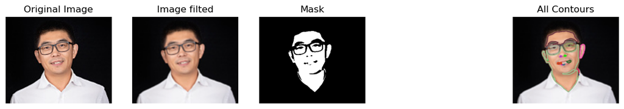

```python
'''对眼镜男图像滤波后的轮廓提取'''
imgGlass = cv2.imread("Images/Glasses.png")
plt.figure(figsize=(14,12))
plt_show('Original Image', imgGlass, 151)

#直接对原始图像进行滤波
imgGlass = cv2.GaussianBlur(imgGlass, (5,5), 2)
# imgGlass = cv2.medianBlur(imgGlass, 5)
# imgGlass = cv2.bilateralFilter(imgGlass,9,100,100)
# imgGlass = cv2.blur(imgGlass, (5, 5))
plt_show('Image filted', imgGlass, 152)

#肤色检测
img_hsv = cv2.cvtColor(imgGlass, cv2.COLOR_BGR2HSV)
lower = np.array([0, 31, 173], dtype = "uint8")
upper = np.array([78, 255, 255], dtype = "uint8")
mask = cv2.inRange(img_hsv, lower, upper)
plt_show('Mask', mask, 153)

#对Mask进行滤波
# mask = cv2.GaussianBlur(mask, (5,5), 2)
# mask = cv2.medianBlur(mask, 5)
# mask = cv2.bilateralFilter(mask,9,100,100)
# mask = cv2.blur(mask, (5, 5))
# mask[mask>0]=255
# plt_show('Mask filted', mask, 154)

#获取轮廓并绘制
contours, hier = cv2.findContours(mask, cv2.RETR_LIST, cv2.CHAIN_APPROX_SIMPLE)

print('轮廓数量：', len(contours))

imgGlassContours = imgGlass.copy()
for i in range(len(contours)):
    cv2.drawContours(imgGlassContours, contours, i, (np.random.randint(0,255), np.random.randint(0,255), np.random.randint(0,255)), 2)
plt_show("All Contours", imgGlassContours, 155)
```

## **2.形态学操作**

形态学，是图像处理中应用最为广泛的技术之一，主要用于从图像中提取对表达和描绘区域形状有意义的图像分量，

使后续的识别工作能够抓住目标对象最为本质的形状特征，如边界和连通区域等。

常用形态学操作有：

- 腐蚀
- 膨胀
- 开运算
- 闭运算
- 梯度运算
- 顶帽运算
- 黑帽运算

参考文档：https://docs.opencv.org/4.x/d9/d61/tutorial_py_morphological_ops.html

### **2.1 膨胀和腐蚀**

膨胀(dilate)与腐蚀（erode）是最基本的形态学操作。

膨胀会使高亮部分区域更大，表现出来的效果就是“领域扩张”；

而腐蚀会让高亮区域更小，表现出来的效果就是“领域被蚕食”。

都是对于白色部分（高亮部分），而不是黑色部分。

它们的作用有：

- 消除噪声
- 连接相邻元素或分割独立的图像元素
- 求图像的梯度

膨胀是求局部最大值的操作，而腐蚀则是求局部最小值的操作。

局部：邻域，术语叫做结构元素（structuring element）或核，是一个0、1二值矩阵，常用$3\times3$的都为1的核，也可以根据需求自定义矩阵的大小和元素值。

如果采用元素值都为1的结构元素，那么：

简单来说膨胀就是以每一个像素点为中心（瞄点），如果其局部区域中包含白色像素，则它也将变成白色；

腐蚀也相反，即以每一个像素点为中心（瞄点），如果其局部区域中包含黑色像素，则它也将变成黑色；

膨胀：

[figure not shown]

腐蚀：

[figure not shown]

更一般的情况，见公式：

膨胀：$${\rm{dst}}({\rm{x}},{\rm{y}}) = \mathop {{\rm{max}}}\limits_{({\rm{x}}\prime ,{\rm{y}}\prime ):{\rm{element}}({\rm{x}}\prime ,{\rm{y}}\prime ) \ne 0} {\rm{src}}({\rm{x}} + {\rm{x}}\prime ,{\rm{y}} + {\rm{y}}\prime )$$

腐蚀： $${\rm{dst}}({\rm{x}},{\rm{y}}) = \mathop {{\rm{min}}}\limits_{({\rm{x}}\prime ,{\rm{y}}\prime ):{\rm{element}}({\rm{x}}\prime ,{\rm{y}}\prime ) \ne 0} {\rm{src}}({\rm{x}} + {\rm{x}}\prime ,{\rm{y}} + {\rm{y}}\prime )$$

#### 采用十字交叉结构元素的膨胀示例：

[figure not shown]

#### 采用十字交叉结构元素的腐蚀示例：

[figure not shown]

#### 2.1.1 膨胀API：

cv2.dilate( src, kernel[, dst[, anchor=Point(-1,-1)[, iterations= 1[, borderType = BORDER_CONSTANT[, borderValue = morphologyDefaultBorderValue()]]]]] ) -> dst

- src：原图（可以是彩色图、灰度图或二值图，一般为二值图）
- kernel：结构元素（核）
- anchor：锚点，默认为Point(-1,-1)，核中心点
- iterations：膨胀次数，默认1次

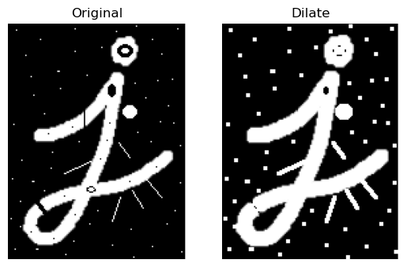

```python
import matplotlib.pyplot as plt
img = cv2.imread('images/morphology.png')

kernel = np.ones((3,3),np.uint8)
imgDilate = cv2.dilate(img,kernel,iterations = 1) #试试改变kernel/iterations

plt_show('Original', img, 121)
plt_show('Dilate', imgDilate, 122)
```

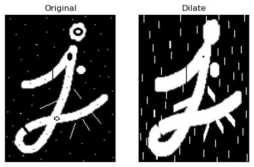

```python
kernel = np.ones((5,1),np.uint8)   #可以根据需要自己定义核
imgDilate = cv2.dilate(img,kernel,iterations = 2)

plt_show('Original', img, 121)
plt_show('Dilate', imgDilate, 122)
```

#### 2.1.2 获得常用结构元素API：

cv2.getStructuringElement( shape, ksize[, anchor= Point(-1,-1)] ) -> retval

- shape：形状，可选的有矩形（MORPH_RECT）、交叉形（MORPH_CROSS）和椭圆形（MORPH_ELLIPSE）
- ksize：结构元大小
- anchor：锚点

```python
#kernel = cv2.getStructuringElement(cv2.MORPH_RECT, (4,4))
kernel = cv2.getStructuringElement(cv2.MORPH_CROSS, (5,5))
# kernel = cv2.getStructuringElement(cv2.MORPH_ELLIPSE, (5,7))
print(kernel)
```

```
[[0 0 1 0 0]
 [0 0 1 0 0]
 [1 1 1 1 1]
 [0 0 1 0 0]
 [0 0 1 0 0]]
```

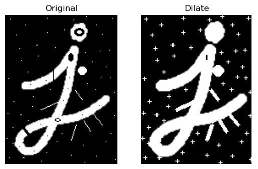

```python
'''使用交叉形结构元进行膨胀'''
kernel = cv2.getStructuringElement(cv2.MORPH_CROSS, (5,5))
imgDilate = cv2.dilate(img,kernel,iterations = 1)

plt_show('Original', img, 121)
plt_show('Dilate', imgDilate, 122)
```

#### **2.1.3 腐蚀API：**

cv2.erode( src, kernel[, dst[, anchor=Point(-1,-1)[, iterations= 1[, borderType = BORDER_CONSTANT[, borderValue = morphologyDefaultBorderValue()]]]]] ) -> dst

参数同膨胀。

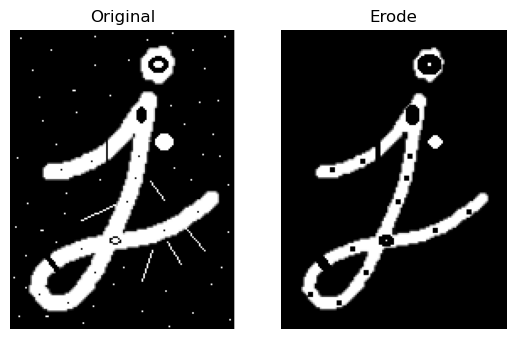

```python
kernel = cv2.getStructuringElement(cv2.MORPH_RECT, (3,3))
imgErode = cv2.erode(img,kernel,iterations = 1)

plt_show('Original', img, 121)
plt_show('Erode', imgErode, 122)
```

### **2.2开运算和闭运算**

- 开运算：先腐蚀，再膨胀
- 闭运算：先膨胀，再腐蚀

开运算的作用：去除孤立的小点和毛刺，在纤细点处分离物体，平滑物体边界的同时而总的位置和形状基本不变（面积改变不明显）。

闭运算的作用：可以用来消除白色区域内的小型孔洞，弥合小裂缝，同样总的位置和形状基本不变。

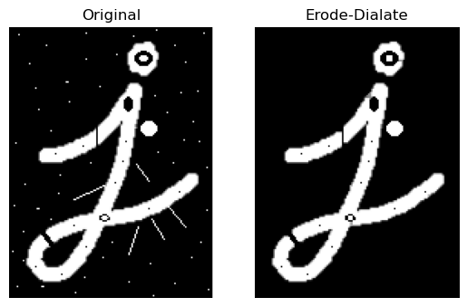

```python
'''先腐蚀，后膨胀'''
kernel = cv2.getStructuringElement(cv2.MORPH_RECT, (3,3))
imgErode = cv2.erode(img,kernel,iterations = 1)
imgErodeDilate = cv2.dilate(imgErode,kernel,iterations = 1)

plt_show('Original', img, 121)
plt_show('Erode-Dialate', imgErodeDilate, 122)
```

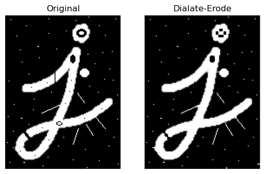

```python
'''先膨胀，后腐蚀'''
kernel = cv2.getStructuringElement(cv2.MORPH_RECT, (3,3))
imgDilate = cv2.dilate(img,kernel,iterations = 1)
imgDilateErode = cv2.erode(imgDilate,kernel,iterations = 1)

plt_show('Original', img, 121)
plt_show('Dialate-Erode', imgDilateErode, 122)
```

#### 开/闭运算API：

cv2.morphologyEx( src, op, kernel[, dst[, anchoranchor=Point(-1,-1)[, iterations= 1[, borderType = BORDER_CONSTANT[, borderValue = morphologyDefaultBorderValue()]]]]] ) -> dst

- op：形态学操作类型，MORPH_ERODE（腐蚀）、MORPH_DILATE（膨胀）、MORPH_OPEN（开运算）、MORPH_CLOSE（闭运算）、MORPH_GRADIENT（梯度运算）、MORPH_TOPHAT（顶帽运算）、MORPH_BLACKHAT（黑帽运算）等

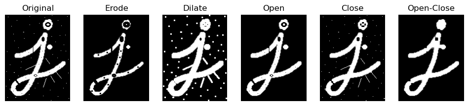

```python
kernel = cv2.getStructuringElement(cv2.MORPH_RECT, (3,3))
imgErode = cv2.morphologyEx(img, cv2.MORPH_ERODE, kernel,iterations = 1)
imgDilate = cv2.morphologyEx(img, cv2.MORPH_DILATE, kernel,iterations = 1)
imgOpen = cv2.morphologyEx(img, cv2.MORPH_OPEN, kernel,iterations = 1)
imgClose = cv2.morphologyEx(img, cv2.MORPH_CLOSE, kernel,iterations = 1)
imgOpenClose = cv2.morphologyEx(imgOpen, cv2.MORPH_CLOSE, kernel,iterations = 2)

plt.figure(figsize=(12,8))
plt_show('Original', img, 161)
plt_show('Erode', imgErode, 162)
plt_show('Dilate', imgDilate, 163)
plt_show('Open', imgOpen, 164)
plt_show('Close', imgClose, 165)
plt_show('Open-Close', imgOpenClose, 166)
```

```
轮廓数量： 1
```

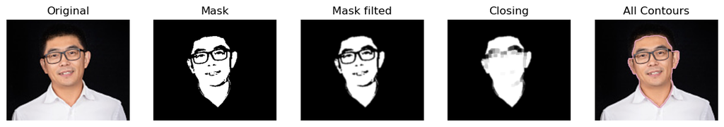

```python
'''对眼镜男肤色检测后图像滤波、再进行闭运算之后的轮廓提取'''
imgGlass = cv2.imread("Images/Glasses.png")

plt.figure(figsize=(14,8))
plt_show('Original', imgGlass, 151)

#肤色检测
img_hsv = cv2.cvtColor(imgGlass, cv2.COLOR_BGR2HSV)
lower = np.array([0, 31, 173], dtype = "uint8")
upper = np.array([78, 255, 255], dtype = "uint8")
mask = cv2.inRange(img_hsv, lower, upper)
plt_show('Mask', mask, 152)

#对Mask进行滤波
mask = cv2.GaussianBlur(mask, (5,5), 2)
# mask = cv2.medianBlur(mask, 5)
# mask = cv2.bilateralFilter(mask,9,100,100)
# mask = cv2.blur(mask, (5, 5))
plt_show('Mask filted', mask, 153)

#闭运算
kernel = cv2.getStructuringElement(cv2.MORPH_RECT, (5,5))
closing = cv2.morphologyEx(mask, cv2.MORPH_CLOSE, kernel, iterations=2)
plt_show('Closing', closing, 154)

#获取轮廓并绘制
contours, hier = cv2.findContours(closing, cv2.RETR_LIST, cv2.CHAIN_APPROX_SIMPLE)

print('轮廓数量：', len(contours))

imgGlassContours = imgGlass.copy()
for i in range(len(contours)):
    cv2.drawContours(imgGlassContours, contours, i, (np.random.randint(0,255), np.random.randint(0,255), np.random.randint(0,255)), 2)
plt_show("All Contours", imgGlassContours, 155)
```

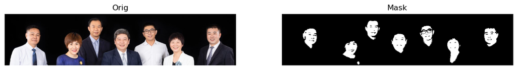

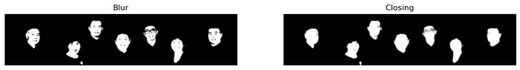

```
8
7 [1, 2, 3, 4, 5, 6, 7]
```

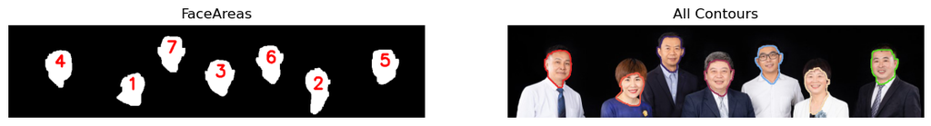

```python
'''同理，得到所有人的人脸分割结果'''
img = cv2.imread("Images/People2.png")

plt.figure(1, figsize=(14,8))
plt_show('Orig',img, 121)

#肤色检测
img_hsv = cv2.cvtColor(img, cv2.COLOR_BGR2HSV)
lower = np.array([0, 31, 173], dtype = "uint8")
upper = np.array([78, 255, 255], dtype = "uint8")
mask = cv2.inRange(img_hsv, lower, upper)
plt_show('Mask',mask, 122)

#对Mask进行滤波
blur = cv2.GaussianBlur(mask, (5,5), 2)
plt.figure(2, figsize=(14,8))
plt_show('Blur', blur, 121)

#闭运算
kernel = np.ones((9,9),np.uint8)
closing = cv2.morphologyEx(blur, cv2.MORPH_CLOSE, kernel)
plt_show('Closing', closing, 122)

#获取轮廓
contours, hier = cv2.findContours(closing, cv2.RETR_EXTERNAL, cv2.CHAIN_APPROX_SIMPLE)

print(len(contours))

#剔除小面积的轮廓
areaLimit = 500
facesIds = []
for i, cnt in enumerate(contours):
    area = cv2.contourArea(cnt)
    if area > areaLimit:
        facesIds.append(i)

print(len(facesIds), facesIds)

#绘制结果
faceAreas = np.zeros_like(img)
imgContours = img.copy()
for i in facesIds:
    cv2.drawContours(imgContours, contours, i, (np.random.randint(0,255), np.random.randint(0,255), np.random.randint(0,255)), 2)
    cv2.drawContours(faceAreas, contours, i, (255, 255, 255), -1)

    M = cv2.moments(contours[i])
    centerX = int(M["m10"] / M["m00"])
    centerY = int(M["m01"] / M["m00"])
    cv2.putText(faceAreas, str(i), (centerX-10, centerY), cv2.FONT_HERSHEY_SIMPLEX, 1.2, (0, 0, 255), 3)

plt.figure(3, figsize=(14,8))
plt_show('FaceAreas', faceAreas, 121)
plt_show("All Contours", imgContours, 122)
```

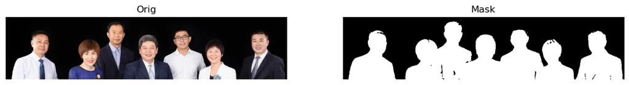

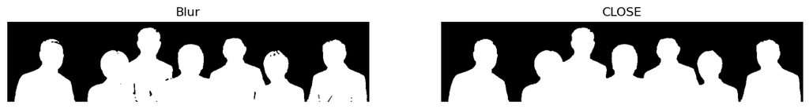

```
3
```

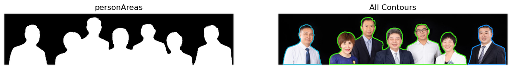

```python
'''同理，得到所有人的人的分割结果'''
img = cv2.imread("Images/People2.png")
plt.figure(1, figsize=(14,8))
plt_show('Orig',img, 121)

imgBlur = cv2.GaussianBlur(img, (3,3), 1)

#前景检测（剔除背景）
img_hsv = cv2.cvtColor(imgBlur, cv2.COLOR_BGR2HSV)
lower = np.array([0, 0, 20], dtype = "uint8")
upper = np.array([255, 255, 255], dtype = "uint8")
mask = cv2.inRange(img_hsv, lower, upper)
plt_show('Mask',mask, 122)

#对Mask进行滤波
blur = cv2.medianBlur(mask, 3)
plt.figure(2, figsize=(14,8))
plt_show('Blur', blur, 121)

#闭运算
kernel = np.ones((3,3),np.uint8)
close = cv2.morphologyEx(blur, cv2.MORPH_CLOSE, kernel, iterations= 2)
plt_show('CLOSE', close, 122)

#获取轮廓
contours, hier = cv2.findContours(close, cv2.RETR_EXTERNAL, cv2.CHAIN_APPROX_SIMPLE)

print(len(contours))

#绘制结果
personAreas = np.zeros_like(img)
imgContours = img.copy()
for contour in contours:
    cv2.drawContours(imgContours, [contour], 0, (np.random.randint(0,255), np.random.randint(0,255), np.random.randint(0,255)), 2)
    cv2.drawContours(personAreas, [contour], 0, (255, 255, 255), -1)

plt.figure(3, figsize=(14,8))
plt_show('personAreas', personAreas, 121)
plt_show("All Contours", imgContours, 122)
```

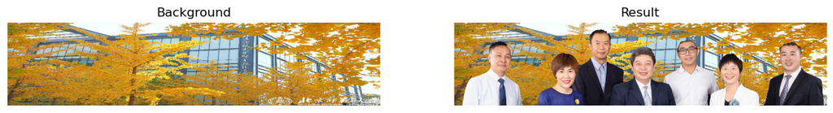

```python
#进一步实现背景替换
img2 = cv2.imread("Images/FallBNU.jpg")
img2 = cv2.resize(img2,(img.shape[1], img.shape[0]))
plt.figure(1, figsize=(14,8))
plt_show('Background', img2, 121)

kernel = cv2.getStructuringElement(cv2.MORPH_RECT, (5,5))
mask = cv2.erode(personAreas[:,:,0],kernel,iterations = 1) #腐蚀一圈

finalback = cv2.bitwise_and(img2, img2, mask = cv2.bitwise_not(mask))
finalpre = cv2.bitwise_and(img, img, mask = mask)
final = finalpre+finalback
plt_show('Result', final, 122)
```

### **2.3形态学梯度**

- 基础梯度：膨胀-腐蚀（OpenCV实现的梯度，morphologyEx中，op取MORPH_GRADIENT）
- 内部梯度：原图-腐蚀
- 外部梯度：膨胀-原图

可以获得类似轮廓的图像。

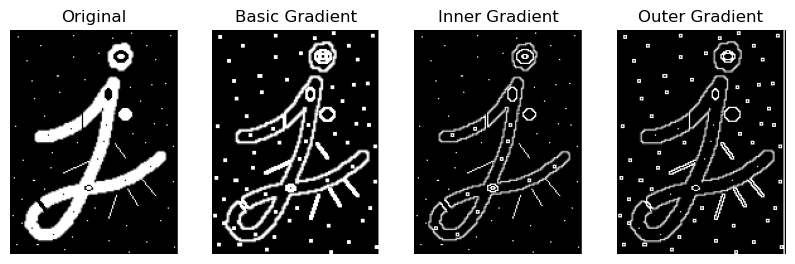

```python
img = cv2.imread('images/morphology.png')

kernel = cv2.getStructuringElement(cv2.MORPH_RECT, (3,3))
imgErode = cv2.erode(img,kernel,iterations = 1)
imgDilate = cv2.dilate(img,kernel,iterations = 1)

imgGrad1 = cv2.morphologyEx(img, cv2.MORPH_GRADIENT, kernel, iterations=1) #同imgDilate-imgErode
imgGrad2 = img - imgErode
imgGrad3 = imgDilate - img

plt.figure(1, figsize=(10,8))
plt_show('Original', img, 141)
plt_show('Basic Gradient', imgGrad1, 142)
plt_show('Inner Gradient', imgGrad2, 143)
plt_show('Outer Gradient', imgGrad3, 144)
```

### **2.4顶帽和黑帽**

- 顶帽：原图-开运算，也称作“礼帽”，可以用来得到比邻近点亮的斑块（黑色区域内的噪声、毛刺）
- 黑帽：闭运算-原图，可以用来得到比邻近点暗的斑块（白色区域里的噪声、孔洞、小裂缝）

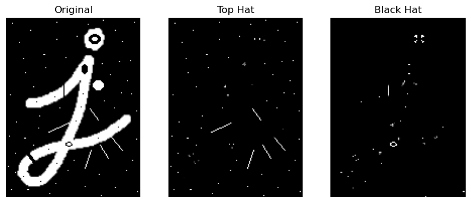

```python
imgTopHat = cv2.morphologyEx(img, cv2.MORPH_TOPHAT, kernel,iterations = 1)
imgBlackHat = cv2.morphologyEx(img, cv2.MORPH_BLACKHAT, kernel,iterations = 1)

plt.figure(1, figsize=(10,8))
plt_show('Original', img, 131)
plt_show('Top Hat', imgTopHat, 132)
plt_show('Black Hat', imgBlackHat, 133)
```

## 作业：

利用今天所学知识自动求解迷宫路线。

[figure not shown]

提示：

[figure not shown]